# Total Sales Revenue

HaiXiao Lu

```r
# import necessary libraries
library(tidyverse)
library(ggplot2)
library(mice)
library(VIM)
library(ggbiplot)
library(MASS)
library(caret)
library("Rtsne")
#library(dplyr)
library(lubridate)
library(magrittr)
library(gridExtra) # display two graph, for grid.arrange
library(data.table)
library(stats)
library(elasticnet)
library(MASS)
library(earth)
library(AppliedPredictiveModeling)
library(glmnet)
```

# (a) Conduct An Exploratory Data Analysis

```r
# Acquire Data
#read in the data
train_df <- read.csv("Train.csv")
test_df <- read.csv("Test.csv")
glimpse(train_df)
glimpse(test_df)

# avaiable features in the dataset
colnames(train_df)
```

## Which features are categorical ? (list 6 categorical variables)

```r
# Categorical features
char <- select_if(train_df, is.character)
head(colnames(char))
```

```
## [1] "date"            "channelGrouping" "browser"         "operatingSystem"
## [5] "deviceCategory"  "continent"
```

## Which features are numerical? (list 6 numeric varaibles)

```r
# which features are numerical?
head(colnames(select_if(train_df, is.numeric)))
```

```
## [1] "sessionId"          "custId"             "visitStartTime"
## [4] "visitNumber"        "timeSinceLastVisit" "isMobile"
```

```r
## Check the overall dataset info
# data summary
dim(train_df)
```

```
## [1] 70071    35
```

```r
dim(test_df)
```

```
## [1] 69672    34
```

# Explore Data Analysis

## EDA1. Univariate Analyses Using Different Plot

### Scatter Plot of Continent vs. Revenue by Pageviews

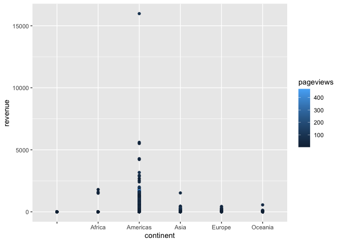

```r
ggplot(data = train_df, aes(x=continent, y = revenue)) +
    geom_point(aes(color = pageviews))
```

#### Findings:

This graph gives us a rough idea which continent has the highest revenue, and it also include what are the pageviews in each continent. This may not accurate because we have a lot of miss values included. However, we still can get a general idea that Americas spent the most money and visited most pages. We also get an outlier that above 15000 dollars in Americas.

### Scatter Plot of Revenue verus Pageviews

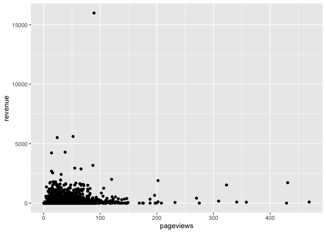

```r
ggplot(data = train_df, aes(x =pageviews, y =revenue )) +
  geom_point()
```

#### Findings:

This graph doesn’t show a strong relationship between pageviews and revenue, but it showed some relationship. Most pageviews range were between 0 and 100, and most of their spendings were below 5000 dollars. As the pageviews increases, it seems that revenue did not go up. There was an outlier in the graph maybe the missing values caused it.

### Facet Plot between Revenue vs. IsMobile by Continent

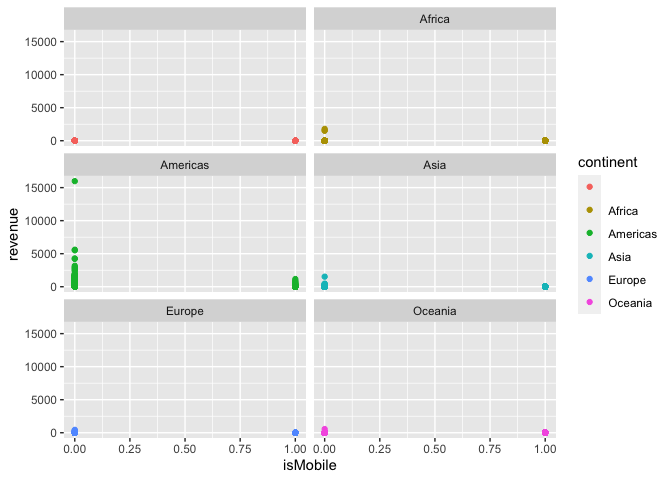

```r
ggplot(data = train_df, aes(x = isMobile, y = revenue, color = continent)) +
  geom_point() +
  facet_wrap(~ continent, nrow = 3)
```

#### Findings:

From this graph we can see majority of customer did not use mobile phone to shop.

## Customer that bought something

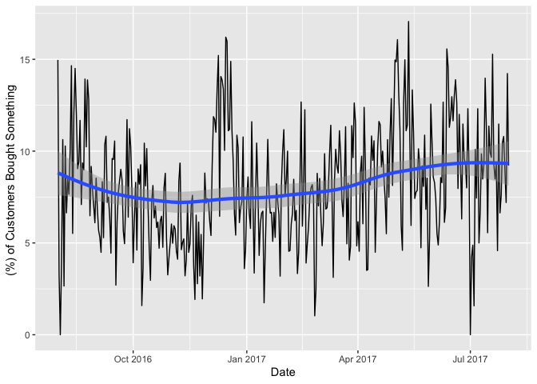

```r
train_df <- train_df %>%
              mutate(target_class = ifelse(as.numeric(revenue) > 0, 1, 0))
train_df %>%
  group_by(date) %>%
  dplyr::summarise(cust_perc = 100 * sum(target_class) / n()) %>%
  ggplot(aes(x = ymd(date), y = cust_perc)) +
  geom_line(colours = "black", size = 0.5) +
  geom_smooth(method = "loess",
              formula = y ~ x,
              size = 1.5) +
  ylab("(%) of Customers Bought Something ") +
  xlab("Date")
```

### Interpertation:

At this point, we can’t tell any obvious trend. But we can see up and downs periodically. I think those ups and downs might have something to do with week and weekends.

## Density Plot of Other Features

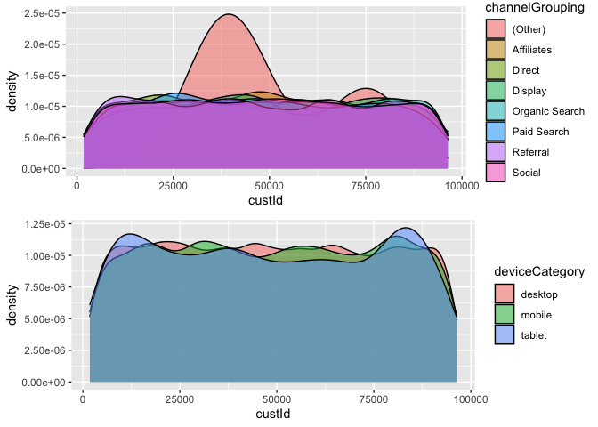

```r
g <- ggplot(data = train_df, aes(x = custId, fill = channelGrouping)) +
     geom_density(alpha=0.5)



g1 <- ggplot(data = train_df, aes(x = custId, fill = deviceCategory)) +
      geom_density(alpha=0.5)


g2 <- ggplot(data = train_df, aes(x = custId, fill = continent)) +
      geom_density(alpha=0.5)


g3 <- ggplot(data = train_df, aes(x = custId, fill = campaign)) +
      geom_density(alpha=0.5)

grid.arrange(g, g1)
```

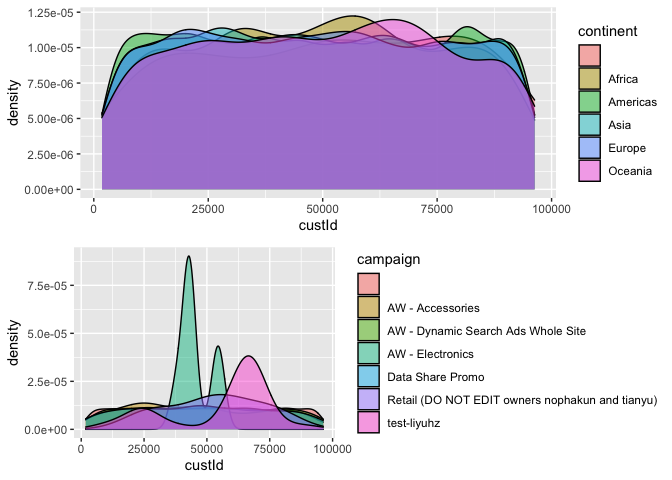

```r
grid.arrange(g2, g3)
```

### Findings:

From all these density plots, we can get some general ideas about what kind of device category most customer use; which channel group has the most customers; which campaign are most customers response to well.

## EDA2. Check out the target variable

```r
# transaction time and total revenue
y <- train_df$revenue # save the original values in a vector
train_df$revenue <- train_df$revenue
train_df %>%
  filter(revenue > 0) %>%
  dplyr::summarize(
    "number of transaction"  = n(),
    'total revenues train set' = sum(revenue)
    )
```

```
##   number of transaction total revenues train set
## 1                  5849                 712279.2
```

## Check out the dollar spent more than 1000

```r
# find min and max dollars spent
# min(train_df[train_df$revenue>0, 35])
# max(train_df$revenue)

# check out the dollar spent more than 1000
train_df %>%
    filter(revenue >= 1000) %>%
    dplyr::summarise('above 1000 USD transaction' = n(),
                     'sum revenues of transactions above 1000 USD' = sum(revenue))
```

```
##   above 1000 USD transaction sum revenues of transactions above 1000 USD
## 1                         84                                    149708.6
```

### Findings:

The range of revenues per transaction is from 0.01 to 15980.79 USD. Of the 5849 transactions, 84 had revenues of at least 1000 USD. The sum of revenues of this tail is about 149708 USD.

### Plots of revenue that below 1000 USD

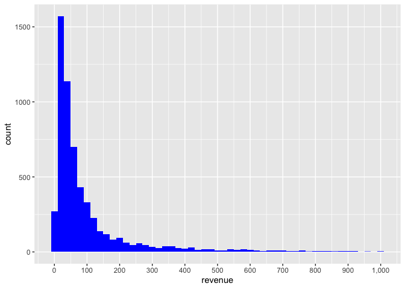

```r
train_df %>%
  dplyr::filter(revenue > 0 & revenue < 1000) %>%
  ggplot(aes(x=revenue)) +
      geom_histogram(fill = 'blue', binwidth = 20) +
      scale_x_continuous(breaks = seq(0, 1000, by = 100), labels = comma)
```

### Findings:

As this plot shows, the distribution of revenues is very right skewed, with the tail reaching to the max amount spent (15980 USD). This histogram only display the transaction with revenues below 1000 USD.

### Revenue by Date

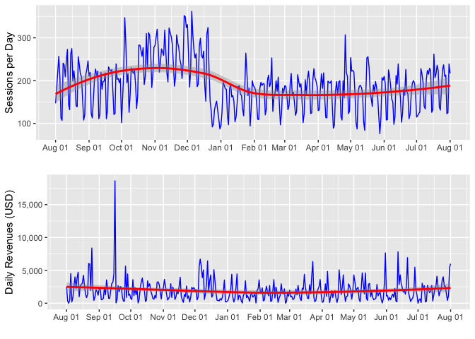

```r
train_df$date <- ymd(train_df$date)
p1 <- train_df %>%
          group_by(date) %>%
          dplyr::summarise(dailySession = n(), .groups = 'drop') %>%
          ggplot(aes(x = date, y = dailySession)) +
          geom_line(col = 'blue') +
          scale_y_continuous(labels = comma) +
          geom_smooth(method = 'loess', col = 'red') +
          labs(x = " ", y = "Sessions per Day") +
          scale_x_date(date_breaks = "1 month", date_labels = "%b %d")

p2 <- train_df %>%
        group_by(date) %>%
        dplyr::summarise(dailyRevenue = sum(revenue)) %>%
        ggplot(aes(x=date, y=dailyRevenue)) +
        geom_line(col='blue') +
        scale_y_continuous(labels=comma) +
        geom_smooth(col='red') +
        labs(x="", y="Daily Revenues (USD)") +
        scale_x_date(date_breaks = "1 month", date_labels = "%b %d")

grid.arrange(p1,p2)
```

### Findings:

The number of daily sessions peaked in October through middle of December, but this did not lead to high revenues. In the revenue plot, we can see highest daily revenue generated between September and October about more than 15000 USD. I think during this period, it generated highest dollar amount that spent (15980 USD).

## 2. Bivariate Analyses

## Scatter plot of all the numeric data

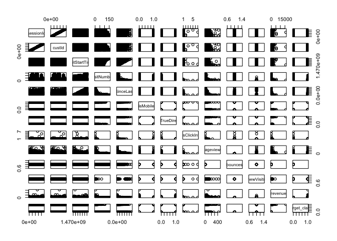

```r
pairs(select_if(train_df, is.numeric))
```

### Findings:

From this scatter plot of all the numerical data that we can’t tell much of relationship between each feature. At this point, we are not sure because of the missingness of the dataset or they don’t relate much initially. But we still can see some information of important relationships between custId, visitStartTime, pageviews and revenue.

## EDA3.Correlation

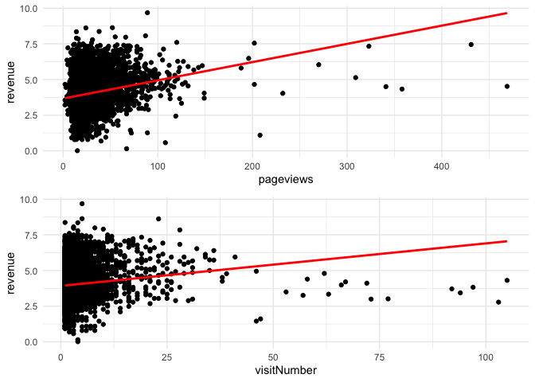

```r
# visualize the relationship of the target variable with each of the correlated variable
p <- train_df %>%
        dplyr::select(pageviews) %>%
        bind_cols(as_tibble(y)) %>%
        filter(value > 0) %>%
        ggplot(aes(x=pageviews, y = log1p(value))) +
        geom_point() +
        labs(x = "pageviews", y = "revenue") +
        geom_smooth(method = "lm",formula = y~x, se = FALSE,color = 'red') +
        theme_minimal()

cp <- train_df %>%
        dplyr::select(visitNumber) %>%
        bind_cols(as_tibble(y)) %>%
        filter(value > 0) %>%
        ggplot(aes(x = visitNumber, y = log1p(value))) +
        geom_point() +
        labs(x = "visitNumber", y = "revenue") +
        geom_smooth(method = "lm", formula = y~x,  se = FALSE, color = 'red') +
        theme_minimal()

grid.arrange(p, cp)
```

### Findings:

From these two plots, we can see there is a positive correlation between revenue vs. pageviews and revenue vs.visitNumber. It kind of make sense though, as people visit the website more often and view more pages, it usually end up buying something, so the revenue goes up as time expands. We need to explore more with these two features. These features can play an important role when we build our model.

### Visiualize the relationship between revenue versus IsTrueDirect

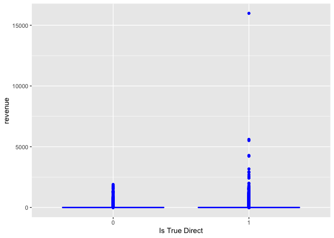

```r
ggplot(data = train_df, aes(x = factor(isTrueDirect), y = revenue)) +
  geom_boxplot(col = "blue") + labs(x = "Is True Direct")
```

### Findings:

We can see there is an outlier in the plot and this outlier is enough to produce a high correlation coefficient. We can see the relationship between isTrueDirect and revenue is not linear. So I guess this is not much of relationship between isTrueDirect and revenue.

## 3. Multivariate Analyses

## EDA4. Overall Missing Proportion and Pattern of Missingness

```r
# Overall missing proportion
cat("The overall missing proportion is: ", mean(is.na(train_df)))
```

```
## The overall missing proportion is:  0.0797568
```

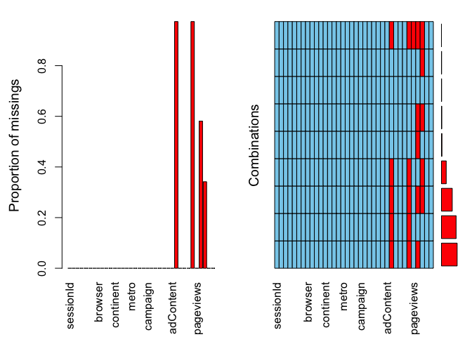

```r
# md.pairs(train_df)
# md.pattern(train_df)
aggr(train_df)
```

## EDA5.PCA Analysis

```r
# filter out redundant variables
train_df$date <- ymd(train_df$date)
train_df$country <- as.factor(train_df$country)
unique_data <- unique(train_df)

# create maxtrix
train_pca <- as.matrix(unique(train_df[,c("sessionId", "custId", "visitStartTime", "visitNumber", "timeSinceLastVisit","isMobile","isTrueDirect", "revenue")]))

# use prcomp to compute PCA
pca <- prcomp(train_pca, center = TRUE, scale. = TRUE)
summary(pca)
```

```
## Importance of components:
##                           PC1    PC2    PC3    PC4    PC5    PC6     PC7
## Standard deviation     1.4144 1.1771 1.0628 0.9917 0.9752 0.9224 0.83601
## Proportion of Variance 0.2501 0.1732 0.1412 0.1229 0.1189 0.1064 0.08736
## Cumulative Proportion  0.2501 0.4233 0.5645 0.6874 0.8063 0.9126 1.00000
##                              PC8
## Standard deviation     3.983e-12
## Proportion of Variance 0.000e+00
## Cumulative Proportion  1.000e+00
```

### Look at PCA Screeplots

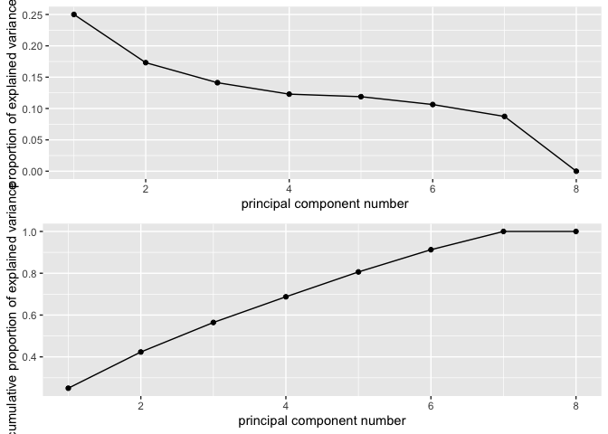

```r
#options(repr.plot.height = 20)
g1 <- ggscreeplot(pca, type = "pev")
g2 <- ggscreeplot(pca, type = "cev")
```

### Findings:

From the pca summary table and those two screeplot, we can definite reduce the dimension around 6. From the summary of pca, we can see that PC6 explains 91% of the total variance. From the screeplots, we can see that there is a break point at PC6. OR we can just reduce to PC4 which based on Cumulative Proportion greater than 68%. However, this pca might not be accurate because we have 3 features such as, pageviews, bounces and adwordsClickInfo.page are not included. Those features have too many missing values.

# (b). Data Preparation(DP)

## DP1. Deletion and Impution Missing Values

### Missing value info

```r
# check which features have missing values
NAcols <- which(colSums(is.na(train_df)) > 0)
NAcount <- sort(colSums(sapply(train_df[NAcols], is.na)), decreasing = TRUE)

# check out the percentage of missingness per variable
myfun <- function(x) mean(is.na(x))

# check which features are containing missing values
tail(apply(train_df, 2, myfun) > 0)
```

```
## adwordsClickInfo.isVideoAd                  pageviews
##                       TRUE                       TRUE
##                    bounces                  newVisits
##                       TRUE                       TRUE
##                    revenue               target_class
##                      FALSE                      FALSE
```

### Percent missing

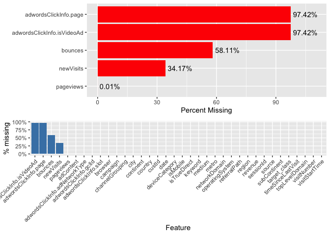

```r
# compute percentage of the missing values
options(repr.plot.height = 4)
NADF <- data.frame(variable = names(NAcount), missing = NAcount)
NADF$PectMissing <- round((NADF$missing/nrow(train_df)*100), 2)
# plot the features that contain missing value
mp <- NADF %>%
      ggplot(aes(x = reorder(variable, PectMissing), y = PectMissing)) +
      geom_bar(stat = 'identity', fill = 'red') + coord_flip(y = c(0, 110)) +
      labs(x = "", y = "Percent Missing") +
      geom_text(aes(label=paste0(PectMissing, '%'), hjust = -0.1))


mp1 <- data.table(
        pmiss = sapply(train_df, function(x) { (sum(is.na(x)) / length(x)) }),
        column = names(train_df)
        ) %>%
      ggplot(aes(x = reorder(column, -pmiss), y = pmiss)) +
      geom_bar(stat = 'identity', fill = 'steelblue') +
      scale_y_continuous(labels = scales::percent) +
      theme(axis.text.x = element_text(angle = 45, hjust = 1)) +
      labs(
          #title='Missing data by feature',
          x='Feature',
          y='% missing')

grid.arrange(mp, mp1)
```

### Deleting Some Missing Value Features

```r
train_df <- subset(train_df,select = -c(adwordsClickInfo.page, adwordsClickInfo.isVideoAd))

# delete test missing values
test_df <- subset(test_df,select = -c(adwordsClickInfo.page, adwordsClickInfo.isVideoAd))

dim(train_df)
```

```
## [1] 70071    34
```

```r
dim(test_df)
```

```
## [1] 69672    32
```

### Interperation:

Since both adwordsClickInfo.page and adwordsClickInfo.isVideoAd features have more than 97% of the missing values. Even if I impute all the missing values in these two features. I have a very low percentage of accuracy. So deletion is just make more sense in this case.

### Imputation of missing values

```r
# setting missing values to zero(percentage missing in train is 58.1%)
train_df$bounces[is.na(train_df$bounces)] <- 0L
test_df$bounces[is.na(test_df$bounces)] <- 0L
train_df %>%
  filter(bounces == 1) %>%
  dplyr::summarise('number of bounces' = n(),
                   'revenue bounce sessions' = sum(revenue))
```

```
##   number of bounces revenue bounce sessions
## 1             29352                       0
```

```r
# setting missing values to one(percentage missing in train is 0.01%)
train_df$pageviews[is.na(train_df$pageviews)] <- 0L
test_df$pageviews[is.na(test_df$pageviews)] <- 0L # test set doesn't make sense
#------------------
# mice package, logreg method to impute missing value
# ?logreg
#------------------------------------
train_df %>%
  filter(pageviews == 1) %>%
  dplyr::summarise('number of 1-page sessions' = n(),
                   'revenue 1-page session' = sum(revenue))
```

```
##   number of 1-page sessions revenue 1-page session
## 1                     29504                      0
```

```r
# set missing value for newVisit to 0 since 1 is first time, otherwise is null

train_df$newVisits[is.na(train_df$newVisits)] <- 0L
test_df$newVisits[is.na(test_df$newVisits)] <- 0L
```

## DP2. Transformations and Aggregation

```r
# converting the date format
train_df$date <- ymd(train_df$date)

# test data set
test_df$date <- ymd(test_df$date)


# # convert raw dates to r data class
aggregateDataTest <- function(train_df){

  train_df$date <- as.Date(as.character(train_df$date))

  # get months for each date
  train_df$month <- month(train_df$date)
  # aggregate data based on custId
    groupedData = train_df %>%
      group_by(custId) %>%
      dplyr::summarise(recordCount = n()
          # average time since last visit
          ,meantimeSinceLastVisit = mean(timeSinceLastVisit)

              #percent of visits by month
              ,pJan = length(month[month==1])/n()
              ,pFeb = length(month[month==2])/n()
              ,pMar = length(month[month==3])/n()
              ,pApr = length(month[month==4])/n()
              ,pMay = length(month[month==5])/n()
              ,pJun = length(month[month==6])/n()
              ,pJul = length(month[month==7])/n()
              ,pAug = length(month[month==8])/n()
              ,pSep = length(month[month==9])/n()
              ,pOct = length(month[month==10])/n()
              ,pNov = length(month[month==11])/n()
              ,pDec = length(month[month==12])/n())
    return(groupedData)

}

fixed_train <- aggregateDataTest(train_df)
glimpse(fixed_train)
```

```
## Rows: 47,249
## Columns: 15
## $ custId                 <int> 1795, 1797, 1799, 1800, 1801, 1803, 1804, 1807…
## $ recordCount            <int> 1, 1, 1, 1, 1, 1, 1, 1, 2, 1, 1, 1, 1, 1, 1, 1…
## $ meantimeSinceLastVisit <dbl> 0.0, 0.0, 0.0, 0.0, 0.0, 0.0, 0.0, 0.0, 8412.5…
## $ pJan                   <dbl> 0, 0, 0, 0, 0, 0, 0, 0, 0, 0, 0, 1, 0, 0, 0, 0…
## $ pFeb                   <dbl> 0, 0, 0, 0, 0, 0, 0, 0, 0, 0, 0, 0, 0, 0, 1, 0…
## $ pMar                   <dbl> 0, 0, 0, 0, 0, 0, 1, 1, 0, 0, 0, 0, 0, 0, 0, 0…
## $ pApr                   <dbl> 1, 0, 0, 0, 0, 0, 0, 0, 0, 0, 0, 0, 0, 0, 0, 0…
## $ pMay                   <dbl> 0, 0, 0, 0, 1, 0, 0, 0, 0, 0, 0, 0, 0, 0, 0, 0…
## $ pJun                   <dbl> 0, 0, 0, 0, 0, 0, 0, 0, 0, 0, 0, 0, 0, 1, 0, 0…
## $ pJul                   <dbl> 0, 0, 0, 0, 0, 0, 0, 0, 0, 0, 0, 0, 0, 0, 0, 0…
## $ pAug                   <dbl> 0, 0, 0, 1, 0, 0, 0, 0, 0, 0, 0, 0, 0, 0, 0, 1…
## $ pSep                   <dbl> 0, 1, 0, 0, 0, 0, 0, 0, 0, 0, 0, 0, 0, 0, 0, 0…
## $ pOct                   <dbl> 0, 0, 0, 0, 0, 1, 0, 0, 0, 0, 0, 0, 0, 0, 0, 0…
## $ pNov                   <dbl> 0, 0, 0, 0, 0, 0, 0, 0, 1, 0, 0, 0, 1, 0, 0, 0…
## $ pDec                   <dbl> 0, 0, 1, 0, 0, 0, 0, 0, 0, 1, 1, 0, 0, 0, 0, 0…
```

```r
which(colSums(is.na(fixed_train)) > 0)
```

```
## named integer(0)
```

### Explanation:

Transformed character type of Date to Date format. Then use function to extract the individual month from Date feature. Then use aggregation to calculate each customer’s average SinceLastVisit time and also calculate the percentage of each month that has customer visited.

## DP3. Collapsing Categories and Feature Extraction

```r
aggregateDateTest <- function(train_df1) {

  groupedData = train_df %>%
      group_by(custId) %>%
      dplyr::summarise(recordCount = n()

                # count by type of channelGrouping
              ,Social = length(channelGrouping[channelGrouping == 'Social'])
              ,OrgSearch = length(channelGrouping[channelGrouping == 'Organic Search'])
              ,Direct = length(channelGrouping[channelGrouping == 'Direct'])
              ,PaidSearch = length(channelGrouping[channelGrouping == 'Paid Search'])
              ,Referral = length(channelGrouping[channelGrouping == 'Referral' ])
              ,Display = length(channelGrouping[channelGrouping == 'Display'])
              ,Affiliates = length(channelGrouping[channelGrouping == 'Affiliates'])
              ,Other = length(channelGrouping[channelGrouping == '(Other)'])

              # count by browser
              ,Chrome = length(browser[browser == 'Chrome'])
              ,Safari = length(browser[browser == 'Safari'])
              ,Firefox = length(browser[browser == 'Firefox'])
              ,InternetExplorer = length(browser[browser == 'Internet Explorer'])
              ,Edge = length(browser[browser == 'Edge'])
              ,BrowserOther = length(browser[(browser != 'Edge'
                                                   & browser != 'Chrome'
                                                   & browser != 'Safari'
                                                   & browser != 'Firefox'
                                                   & browser != 'Internet Explorer')])

              # count by OS
              ,Macintosh = length(operatingSystem[operatingSystem=='Macintosh'])
              ,Windows = length(operatingSystem[operatingSystem=='Windows'])
              ,Android = length(operatingSystem[operatingSystem=='Android'])
              ,iOS = length(operatingSystem[operatingSystem=='iOS'])
              ,ChromeOS = length(operatingSystem[operatingSystem=='Chrome OS'])
              ,Linux = length(operatingSystem[operatingSystem=='Linux'])
              ,OSOther = length(browser[(operatingSystem !='Macintosh'
                                              & operatingSystem !='Windows'
                                              & operatingSystem !='Android'
                                              & operatingSystem !='iOS'
                                              & operatingSystem !='Chrome OS'
                                              & operatingSystem !='Linux')])

            # create device variables
              ,Desktop = length(deviceCategory[deviceCategory=='desktop'])
              ,Mobile = length(deviceCategory[deviceCategory=='mobile'])
              ,Tablet = length(deviceCategory[deviceCategory=='tablet'])

      )
  return(groupedData)

}
fixed_train <- aggregateDateTest(train_df1)
```

### Explanation:

Collapsed browser, operatingSystem, deviceCategory and ChannelGrouping features, and extracted sub-features from each feature into new single feature. For example, we don’t have a huge browser feature which contains all kind of browsers anymore. Now we have single feature like chrome, safari…etc.

## DP4. Aggregatations, Feature Extraction, Collapsing Categories

```r
# create function
aggregateDataTest <- function(train_df2) {

    # aggregate data based on custId
    groupedData = train_df %>%
      group_by(custId) %>%
      dplyr::summarise(recordCount = n()

              #create continent variables
              ,cntAmericas = length(continent[continent=='Americas'])
              ,cntAsia = length(continent[continent=='Asia'])
              ,cntEurope = length(continent[continent=='Europe'])
              ,cntOceania = length(continent[continent=='Oceania'])
              ,cntNull = length(continent[continent==""])

              #create country variables for top 10
              ,US = length(country[country=="United States"])
              ,India = length(country[country=="India"])
              ,UK = length(country[country=="United Kingdom"])
              ,Canada = length(country[country=="Canada"])
              ,Vietnam = length(country[country=="Vietnam"])
              ,Turkey = length(country[country=="Turkey"])
              ,Thailand = length(country[country=="Thailand"])
              ,Germany = length(country[country=="Germany"])
              ,Brazil = length(country[country=="Brazil"])
              ,Japan = length(country[country=="Japan"])
              ,CountryOther = length(country[(country !='United States'
                                                   & country !='India'
                                                   & country !='United Kingdom'
                                                   & country !='Canada'
                                                   & country !='Vietnam'
                                                   & country !='Turkey'
                                                   & country !='Thailand'
                                                   & country !='Germany'
                                                   & country !='Brazil'
                                                   & country !='Japan'

              )])
              #top 10 sources
              ,srcGoogle = length(source[source=="google"])
              ,srcyoutube = length(source[source=="youtube.com"])
              ,srcDirect = length(source[source=="(direct)"])
              ,srcGooglePlex = length(source[source=="mall.googleplex.com"])
              ,srcPartners = length(source[source=="Partners"])
              ,srcGoogleAnalytics = length(source[source=="analytics.google.com"])
              ,srcDfa = length(source[source=="dfa"])
              ,srcGoogleCom = length(source[source=="google.com"])
              ,srcGoogleSites = length(source[source=="sites.google.com"])
              ,srcFacebook = length(source[source=="m.facebook.com"])
              ,srcOther = length(source[(  source !='google'
                                                    & source !='youtube.com'
                                                    & source !='(direct)'
                                                    & source !='mall.googleplex.com'
                                                    & source !='Partners'
                                                    & source !='analytics.google.com'
                                                    & source !='dfa'
                                                    & source !='google.com'
                                                    & source !='sites.google.com'
                                                    & source !='m.facebook.com'
              )])
              #medium variables
              ,medOrganic = length(medium[medium=="organic"])
              ,medReferral = length(medium[medium=="referral"])
              ,medNull = length(medium[medium] == "")
              ,medCpc = length(medium[medium=="cpc"])
              ,medAffiliate = length(medium[medium=="affiliate"])
              ,medCpm = length(medium[medium=="cpm"])

      )
    return(groupedData)
}
fixed_train <- aggregateDataTest(train_df2)
```

### Explanation:

Using collapsing categories and feature extraction to create new category. Extracted several individual features from one feature, such as created 5 different continent features after extracted from continent feature. Also, some new features were created like, countryOther, continentNull, ect.

## DP5. Aggregation, Feature Engineering

```r
# create function
aggregateDataTest <- function(train_df) {

    # aggregate data based on custId
    groupedData = train_df %>%
      group_by(custId) %>%
      dplyr::summarise(recordCount = n()

              #create sum of pageviews
              ,sumPageViews = sum(pageviews)

              # create log sum of revenue
              ,logSumRevenue = log(sum(revenue) + 1)

      )

    # return dataset
   return(groupedData)
}


#an example application of the function
fixed_train <- aggregateDataTest(train_df)
```

### Explanation:

Use aggregation to aggregate customer based sum of pageviews and log of sum revenue. This will help to build the model and obey the rules for log of sum revenue

# (c). Preparing Modeling

```r
# apply to test dataset
 aggregateDataTest1 <- function(test_df){

  test_df$date <- as.Date(as.character(test_df$date))
  test_df$visitStartTime = as.POSIXct(test_df$visitStartTime, origin = "1970-01-01")

  # get months for each date
  test_df$month <- month(test_df$date)
  # aggregate data based on custId
    groupedData <- test_df %>%
      group_by(custId) %>%
      dplyr::summarise(recordCount = n()
          # average time since last visit
          ,meantimeSinceLastVisit = mean(timeSinceLastVisit)

              #percent of visits by month
              ,pJan = length(month[month==1])/n()
              ,pFeb = length(month[month==2])/n()
              ,pMar = length(month[month==3])/n()
              ,pApr = length(month[month==4])/n()
              ,pMay = length(month[month==5])/n()
              ,pJun = length(month[month==6])/n()
              ,pJul = length(month[month==7])/n()
              ,pAug = length(month[month==8])/n()
              ,pSep = length(month[month==9])/n()
              ,pOct = length(month[month==10])/n()
              ,pNov = length(month[month==11])/n()
              ,pDec = length(month[month==12])/n()

     # count by type of channelGrouping
              ,Social = length(channelGrouping[channelGrouping == 'Social'])
              ,OrgSearch = length(channelGrouping[channelGrouping == 'Organic Search'])
              ,Direct = length(channelGrouping[channelGrouping == 'Direct'])
              ,PaidSearch = length(channelGrouping[channelGrouping == 'Paid Search'])
              ,Referral = length(channelGrouping[channelGrouping == 'Referral' ])
              ,Display = length(channelGrouping[channelGrouping == 'Display'])
              ,Affiliates = length(channelGrouping[channelGrouping == 'Affiliates'])
              ,Other = length(channelGrouping[channelGrouping == '(Other)'])

              # count by browser
              ,Chrome = length(browser[browser == 'Chrome'])
              ,Safari = length(browser[browser == 'Safari'])
              ,Firefox = length(browser[browser == 'Firefox'])
              ,InternetExplorer = length(browser[browser == 'Internet Explorer'])
              ,Edge = length(browser[browser == 'Edge'])
              ,BrowserOther = length(browser[(browser != 'Edge'
                                                   & browser != 'Chrome'
                                                   & browser != 'Safari'
                                                   & browser != 'Firefox'
                                                   & browser != 'Internet Explorer')])

              # count by OS
              ,Macintosh = length(operatingSystem[operatingSystem=='Macintosh'])
              ,Windows = length(operatingSystem[operatingSystem=='Windows'])
              ,Android = length(operatingSystem[operatingSystem=='Android'])
              ,iOS = length(operatingSystem[operatingSystem=='iOS'])
              ,ChromeOS = length(operatingSystem[operatingSystem=='Chrome OS'])
              ,Linux = length(operatingSystem[operatingSystem=='Linux'])
              ,OSOther = length(browser[(operatingSystem !='Macintosh'
                                              & operatingSystem !='Windows'
                                              & operatingSystem !='Android'
                                              & operatingSystem !='iOS'
                                              & operatingSystem !='Chrome OS'
                                              & operatingSystem !='Linux')])

            # create device variables
              ,Desktop = length(deviceCategory[deviceCategory=='desktop'])
              ,Mobile = length(deviceCategory[deviceCategory=='mobile'])
              ,Tablet = length(deviceCategory[deviceCategory=='tablet'])

              #create continent variables
              ,cntAmericas = length(continent[continent=='Americas'])
              ,cntAsia = length(continent[continent=='Asia'])
              ,cntEurope = length(continent[continent=='Europe'])
              ,cntOceania = length(continent[continent=='Oceania'])
              ,cntNull = length(continent[continent==""])

              #create country variables for top 10
              ,US = length(country[country=="United States"])
              ,India = length(country[country=="India"])
              ,UK = length(country[country=="United Kingdom"])
              ,Canada = length(country[country=="Canada"])
              ,Vietnam = length(country[country=="Vietnam"])
              ,Turkey = length(country[country=="Turkey"])
              ,Thailand = length(country[country=="Thailand"])
              ,Germany = length(country[country=="Germany"])
              ,Brazil = length(country[country=="Brazil"])
              ,Japan = length(country[country=="Japan"])
              ,CountryOther = length(country[(country !='United States'
                                                   & country !='India'
                                                   & country !='United Kingdom'
                                                   & country !='Canada'
                                                   & country !='Vietnam'
                                                   & country !='Turkey'
                                                   & country !='Thailand'
                                                   & country !='Germany'
                                                   & country !='Brazil'
                                                   & country !='Japan'

              )])
              #top 10 sources
              ,srcGoogle = length(source[source=="google"])
              ,srcyoutube = length(source[source=="youtube.com"])
              ,srcDirect = length(source[source=="(direct)"])
              ,srcGooglePlex = length(source[source=="mall.googleplex.com"])
              ,srcPartners = length(source[source=="Partners"])
              ,srcGoogleAnalytics = length(source[source=="analytics.google.com"])
              ,srcDfa = length(source[source=="dfa"])
              ,srcGoogleCom = length(source[source=="google.com"])
              ,srcGoogleSites = length(source[source=="sites.google.com"])
              ,srcFacebook = length(source[source=="m.facebook.com"])
              ,srcOther = length(source[(  source !='google'
                                                    & source !='youtube.com'
                                                    & source !='(direct)'
                                                    & source !='mall.googleplex.com'
                                                    & source !='Partners'
                                                    & source !='analytics.google.com'
                                                    & source !='dfa'
                                                    & source !='google.com'
                                                    & source !='sites.google.com'
                                                    & source !='m.facebook.com'
              )])
              #medium variables
              ,medOrganic = length(medium[medium=="organic"])
              ,medReferral = length(medium[medium=="referral"])
              ,medNull = length(medium[medium] == "")
              ,medCpc = length(medium[medium=="cpc"])
              ,medAffiliate = length(medium[medium=="affiliate"])
              ,medCpm = length(medium[medium=="cpm"])

              ,hourOfDay = hour(visitStartTime)

              ,isMobile = ifelse(isMobile, 1L, 0L)
              ,isTrueDirect = ifelse(isTrueDirect, 1L, 0L)

               #create sum of pageviews
              ,logPageViews = log(sum(pageviews))

              # log of newVisit
              ,lognewVisits = sum(newVisits)

      )
    return(groupedData)

 }
fixed_test <- aggregateDataTest1(test_df)
glimpse(fixed_test)
```

```r
which(colSums(is.na(fixed_train)) > 0)
 # remove singlularity
 fixed_tr <- fixed_train[,apply(fixed_train, 2, var, na.rm=TRUE) != 0]

 #remove high cor
tr_df <- cor(fixed_train)
tr_df[upper.tri(tr_df)] <- 0
diag(tr_df) <- 0
 tr_new <- fixed_train[,!apply(tr_df, 2, function(x) any (x >0.99))]
head(tr_new)
```

# (d). Modeling

## Modeling

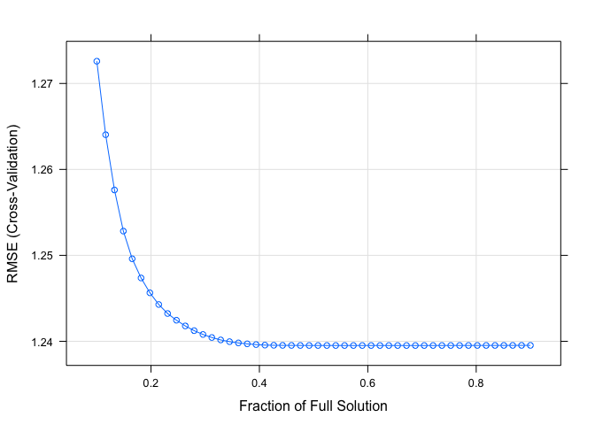

```r
# Linear model, bootstrap resampling
fit <- lm(data = tr_new, logSumRevenue~.,)
summary(fit)
anova(fit)
RSS <- c(crossprod(fit$residuals))
MSE <- RSS / length(fit$residuals)
RMSE <- sqrt(MSE)



# model 7
fit7 <- update (fit, ~.-recordCount -  meantimeSinceLastVisit-pOct-Mobile-srcGoogle - pJul -
                 Chrome - Desktop - cntAsia - cntOceania - srcDirect - srcOther - cntEurope-
                  pApr - pJan - srcyoutube- srcDfa - cntNull - Germany - srcGoogleAnalytics-
                  srcGoogleCom - srcFacebook - CountryOther - Japan - Tablet - Linux - iOS-
                  Windows - Safari - pSep - pJun - pFeb - OSOther - pMar - custId - Other -
                  srcPartners - medOrganic - medReferral - medNull - medCpc - medAffiliate-
                  medCpm)
summary(fit7)
anova(fit7)
RSS <- c(crossprod(fit7$residuals))
MSE <- RSS / length(fit7$residuals)
RMSE7 <- sqrt(MSE)
# revise model, exclude some variables that contains high p value
fit1 <- update(fit, ~.-Social-Other - OrgSearch
               - Direct - PaidSearch - Referral -
                 Display - Affiliates - srcGoogle -
                 srcyoutube - srcGooglePlex - srcPartners - srcDirect -
                 srcGoogleAnalytics - srcDfa - srcGoogleCom -
                 srcGoogleSites - srcFacebook - srcOther - medOrganic - medCpc -
                 medAffiliate - medCpm - medNull - medReferral)
summary(fit1)
RSS <- c(crossprod(fit1$residuals))
MSE <- RSS / length(fit1$residuals)
RMSE1 <- sqrt(MSE)

# revise model
fit2 <- update(fit, ~. -Chrome - Safari - Firefox -
                 InternetExplorer - Edge - BrowserOther)

summary(fit2)
RSS <- c(crossprod(fit2$residuals))
MSE <- RSS / length(fit2$residuals)
RMSE2 <- sqrt(MSE)

# revise model
fit3 <- update(fit, ~. -cntAmericas - cntAsia - cntEurope -
    cntOceania - cntNull)
summary(fit3)
RSS <- c(crossprod(fit3$residuals))
MSE <- RSS / length(fit3$residuals)
RMSE3 <- sqrt(MSE)

# revise model
fit4 <- update(fit, ~. -Macintosh - Windows - Android - iOS -
              ChromeOS - Linux - OSOther)
summary(fit4)
RSS <- c(crossprod(fit4$residuals))
MSE <- RSS / length(fit4$residuals)
RMSE4 <- sqrt(MSE)


fit5 <- update(fit, ~.  - Desktop - Mobile - Tablet)
summary(fit5)
RSS <- c(crossprod(fit5$residuals))
MSE <- RSS / length(fit5$residuals)
RMSE5 <- sqrt(MSE)

fit6 <- update(fit, ~.-pJan - pFeb - pMar - pApr
            -pMay - pAug - pSep -  pJun - pJul  -
                pOct- pNov - pDec )
summary(fit6)
RSS <- c(crossprod(fit6$residuals))
MSE <- RSS / length(fit6$residuals)
RMSE6 <- sqrt(MSE)

RMSE
RMSE1
RMSE2
RMSE3
RMSE4
RMSE5
RMSE6
RMSE7

##---------------use caret package-----------------
library(caret)
fit_caret <- train(logSumRevenue~.,
                   data = tr_new,
                   method = "lm")

fit_caret
summary(fit_caret)
fit_caret$finalModel

# adjust resampling parameters using "trControl"
myControl <- trainControl(method = "cv", number =10)

fit_caret1 <- train(logSumRevenue~.,
                    data = fixed_tr,
                    method = "lasso",
                    trControl = myControl,
                    tuneLength = 50)

fit_caret1
plot(fit_caret1)
```

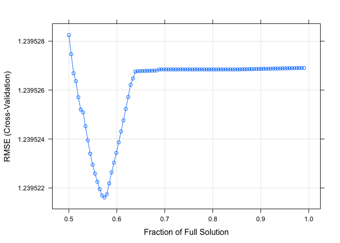

```r
## specifying exactly the hyperparameter values to use with "expand.grid"
fixed_tr <- fixed_train[,apply(fixed_train, 2, var, na.rm=TRUE) != 0]
lasso_grid <- expand.grid(fraction = seq(0.5, 0.99, length = 100))

fit_caret2 <- train(logSumRevenue~.,
                    data = fixed_tr,
                    method = "lasso",
                    trControl = myControl,
                    tuneGrid = lasso_grid)

fit_caret2
plot(fit_caret2)
```

# Stepwise Regression

```r
# fit a linear model and now focus on fixing multicollinearity
model.ls <- fit
coef(model.ls)
# compute the mean of residual sum of squares
rss.ls <- sum(model.ls$residuals^2) / model.ls$df.residual

# -------stepwise regression------

## backward stepwise
model.backward <- step(model.ls, direction = "backward")
summary(model.backward)
rss.backward <- sum(model.backward$residuals^2) / model.backward$df.residual
RSS <- c(crossprod(model.backward$residuals))
MSE <- RSS / length(model.backward$residuals)
RMSE_backward <- sqrt(MSE)


## Forward step
scope <- list(upper=~logSumRevenue ~ custId  + meantimeSinceLastVisit +
    pJan + pFeb + pMar + pApr + pMay + pJun +
    pJul + pAug + pSep + pOct + pNov + pDec +
    Referral +  Other +
    Chrome + Safari + Firefox + InternetExplorer +
    Edge + BrowserOther + Macintosh + Windows +
    Android + iOS + ChromeOS + Linux + OSOther +
    Desktop + Mobile + Tablet + cntAmericas +
    cntAsia + cntEurope + cntOceania + cntNull + US +
    India + UK + Canada + Vietnam + Turkey +
    Thailand + Germany + Brazil + Japan +
    CountryOther  + srcyoutube + srcGooglePlex +
  srcGoogleAnalytics + srcGoogleCom +
    srcGoogleSites + srcFacebook + medOrganic + medCpc +
    medAffiliate + logPageViews + isMobile + isTrueDirect, lower = ~.)

models.forward <- step(lm(logSumRevenue ~ 1, data = tr_new),
                      scope, direction = "forward")
summary(models.forward)
RSS <- c(crossprod(models.forward$residuals))
MSE <- RSS / length(models.forward$residuals)
RMSE_forward <- sqrt(MSE)

rss.forward <- sum(models.forward$resid^2)/models.forward$df.residual


# both backward and forward
model.both <- stepAIC(fit, direction = "both")
summary(model.both)
model.both$anova
RSS <- c(crossprod(model.both$residuals))
MSE <- RSS / length(model.both$residuals)
RMSE_both <- sqrt(MSE)
```

## Ridge Regression

```r
# ridge
y <- as.numeric(unlist(tr_new[,68]))    #target variable
x <- as.matrix(tr_new[,1:67])


lambdas <- 10^seq(2, -3, by = -.1)
cv_ridge <- cv.glmnet(x, y, alpha = 0, lambda = lambdas)
summary(cv_ridge)
optimal_lambda <- cv_ridge$lambda.min
optimal_lambda

# compute R^2 from true and predicted values
eval_results <- function(true, predicted, df){
  SSE <- sum((predicted - true)^2)
  SST <- sum((true - mean(true))^2)
  R_square <- 1 - SSE / SST
  RMSE = sqrt(SSE/nrow(df))


  # Model performance metrics
data.frame(
  RMSE = RMSE,
  Rsquare = R_square
)

}

# prediction and evaluation on train data
predictions_train <- predict(cv_ridge, s = optimal_lambda, newx = x)

eval_results(y, predictions_train, tr_new)
```

## Lasso Regression

```r
y <- as.numeric(unlist(tr_new[,68]))    #target variable
x <- as.matrix(tr_new[,1:67])

# setting alpha = 1 implements lasso regression
lasso_reg <- cv.glmnet(x, y, alpha = 1,
                       lambda = lambdas,
                       standardize = TRUE,
                       nfolds = 5)

# best lambda
lambda_best <- lasso_reg$lambda.min
lambda_best

lasso_model <- glmnet(x, y, alpha = 1,
                      lambda = lambda_best,
                      standardize = TRUE)

predictions_train <- predict(lasso_model, s = lambda_best, newx = x)
eval_results(y, predictions_train, tr_new)
```

## Partinal Least squares

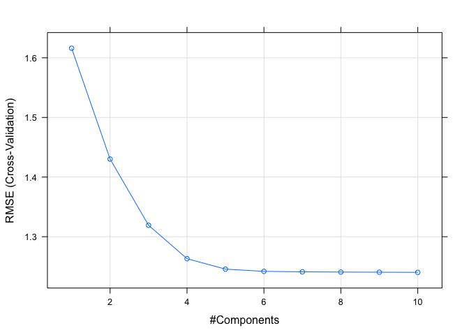

```r
library(pls)

set.seed(1243)
model_pls <- train(logSumRevenue~., data = tr_new,
                   method = "pls",
                   scale = TRUE,
                   trControl = trainControl("cv", number = 10),
                   tuneLength = 10)

plot(model_pls)
```

```r
#print the best tuning parameter
model_pls$bestTune
summary(model_pls$finalModel)

predictions_train <- predict(model_pls, s = model_pls$bestTune, newx = x)
eval_results(y, predictions_train, tr_new)
```

## Elastic Net Regression

```r
train_ctr <- trainControl(method = "repeatedcv",
                          number = 10,
                          repeats = 5,
                          search = "random",
                          verboseIter = TRUE)

# Train the model
elastic_reg <- train(logSumRevenue~.,
                     data = tr_new,
                     method = "glmnet",
                     preProcess = c("center", "scale"),
                     tnueLength = 10,
                     trControl = train_ctr)

#best tune parameter
elastic_reg$bestTune

# Make predictions on training set
predictions_train <- predict(elastic_reg, x)
eval_results(y, predictions_train, tr_new)
```